# Downstream analysis

Gabriel Mateus Bernardo Harrington

2021-03-20 15:41:47

# 1 Load packages

```r
library(dplyr)
library(readr)
library(magrittr)
library(ggplot2)
## Bioconductor packages
library(BiocManager)
## BiocManager::install("tximport")
library(tximport)
library(DESeq2)
```

# 2 Read in data

```r
## read in sample tabe
sample_table <- read_csv("sample_table.csv")
sample_table
```

| dir_names | sample_name | treatment |
| --- | --- | --- |
| 1-16081_Nor_Cells_AGTCAAAT_L001_ | 1-16081 | normoxia_cells |
| 13-16143_Nor_Cells_CGATGTAT_L001_ | 13-16143 | normoxia_cells |
| 17-No_1_16081_Nor_EV_AGTTCCAT_L001_ | 17-No_1_16081 | normoxia_ev |
| 18-No_2_16082_Nor_EV_TTAGGCAT_L001_ | 18-No_2_16082 | normoxia_ev |
| 19-No_3_16088_Nor_EV_TGACCAAT_L001_ | 19-No_3_16088 | normoxia_ev |
| 20-No_4_16143_Nor_EV_ACAGTGAT_L001_ | 20-No_4_16143 | normoxia_ev |
| 21-No_5_16081_Hyp_EV_GCCAATAT_L001_ | 21-No_5_16081 | hypoxia_ev |
| 22-No_6_16082_Hyp_EV_ATGTCAAT_L001_ | 22-No_6_16082 | hypoxia_ev |
| 23-No_7_16088_Hyp_EV_CAGATCAT_L001_ | 23-No_7_16088 | hypoxia_ev |
| 24-No_8_16143_Hyp_EV_ACTTGAAT_L001_ | 24-No_8_16143 | hypoxia_ev |

[output cut: 7 more lines]

```r
## make vector of paths to salmon outputs
salmon_dirs = "../../../RNA_seq_mairead_2021-03-16/trimmed_manual/"
salmon_files <- paste0(salmon_dirs, pull(sample_table, dir_names), "/quant.sf")
names(salmon_files) <- pull(sample_table, sample_name)
head(salmon_files, 3)
```

```
##                                                                                           1-16081                                                                                          13-16143
##    "../../../RNA_seq_mairead_2021-03-16/trimmed_manual/1-16081_Nor_Cells_AGTCAAAT_L001_/quant.sf"   "../../../RNA_seq_mairead_2021-03-16/trimmed_manual/13-16143_Nor_Cells_CGATGTAT_L001_/quant.sf"
##                                                                                     17-No_1_16081
## "../../../RNA_seq_mairead_2021-03-16/trimmed_manual/17-No_1_16081_Nor_EV_AGTTCCAT_L001_/quant.sf"
```

```r
## read in gene maps
gene_map <- read_csv("gene_map.csv", col_names = c("enstid", "ensgid"))
gene_map
```

| enstid | ensgid |
| --- | --- |
| ENST00000456328 | ENSG00000223972 |
| ENST00000450305 | ENSG00000223972 |
| ENST00000488147 | ENSG00000227232 |
| ENST00000619216 | ENSG00000278267 |
| ENST00000473358 | ENSG00000243485 |
| ENST00000469289 | ENSG00000243485 |
| ENST00000607096 | ENSG00000284332 |
| ENST00000417324 | ENSG00000237613 |
| ENST00000461467 | ENSG00000237613 |
| ENST00000606857 | ENSG00000268020 |

[output cut: 9990 more lines]

```r
## read in salmon outputs
count_data <- tximport(files = salmon_files, type = "salmon",
         tx2gene = gene_map,
         ignoreTxVersion = TRUE) #ignore "." after gene id

## check output
str(count_data)
```

```
## List of 4
##  $ abundance          : num [1:60232, 1:17] 0.00156 0 0.08014 0.00425 0 ...
##   ..- attr(*, "dimnames")=List of 2
##   .. ..$ : chr [1:60232] "ENSG00000000003" "ENSG00000000005" "ENSG00000000419" "ENSG00000000457" ...
##   .. ..$ : chr [1:17] "1-16081" "13-16143" "17-No_1_16081" "18-No_2_16082" ...
##  $ counts             : num [1:60232, 1:17] 1 0 7 1 0 ...
##   ..- attr(*, "dimnames")=List of 2
##   .. ..$ : chr [1:60232] "ENSG00000000003" "ENSG00000000005" "ENSG00000000419" "ENSG00000000457" ...
##   .. ..$ : chr [1:17] "1-16081" "13-16143" "17-No_1_16081" "18-No_2_16082" ...
##  $ length             : num [1:60232, 1:17] 3518 624 479 1288 2181 ...
##   ..- attr(*, "dimnames")=List of 2
##   .. ..$ : chr [1:60232] "ENSG00000000003" "ENSG00000000005" "ENSG00000000419" "ENSG00000000457" ...
##   .. ..$ : chr [1:17] "1-16081" "13-16143" "17-No_1_16081" "18-No_2_16082" ...
##  $ countsFromAbundance: chr "no"
```

```r
dim(count_data[['counts']])
```

```
## [1] 60232    17
```

```r
# prep sample data for deseq
sample_table <- as.data.frame(sample_table)
sample_table$treatment <- as.factor(sample_table$treatment)
# get tximport output to deseq
deseq_data_in <- DESeqDataSetFromTximport(txi = count_data,
                                       colData = sample_table,
                                       design = ~ treatment)

## check counts
counts(deseq_data_in)[1:6, 1:3]
```

```
##                 1-16081 13-16143 17-No_1_16081
## ENSG00000000003       1        0             0
## ENSG00000000005       0        0             0
## ENSG00000000419       7        0             0
## ENSG00000000457       1        0            15
## ENSG00000000460       0        0             0
## ENSG00000000938       0        0             0
```

```r
count_data$counts[1:6, 1:3]
```

```
##                 1-16081 13-16143 17-No_1_16081
## ENSG00000000003   1.001        0             0
## ENSG00000000005   0.000        0             0
## ENSG00000000419   7.000        0             0
## ENSG00000000457   1.000        0            15
## ENSG00000000460   0.000        0             0
## ENSG00000000938   0.000        0             0
```

# 3 Normalisation

Reads map to a gene in proportion to:

- Gene length
- Gene expression
- Library depth

We are only interested in differential gene expression, so we’re not interested if one gene has twice as many counts as another simply because it’s twice as long. But we are also comparing the same genes in different conditions, so gene length doesn’t matter to us.

Library depth effect does matter though. If you sequence 10 million reads for one library and 20 million reads for another library, the second will have twice as many counts for every gene regardless of any expression effects.

We therefore need to normalise this effect away, so that any difference in counts are due to gene expression alone.

DESeq2 has a method this by “*Trimmed median of means (TMM)*.”

TMM steps are as follows:

- per row geometric mean of counts
- per row ratio of counts to geometric mean
- median of these ratios for a sample (column) = ‘scaling factor’
- Raw counts/scaling factor = normalised counts

```r
# apply TMM
deseq_data <- estimateSizeFactors(deseq_data_in)
## check normalized factors and counts
head(normalizationFactors(deseq_data))[, 1:3]
```

```
##                  1-16081 13-16143 17-No_1_16081
## ENSG00000000003 3.996512 3.658553     0.7648307
## ENSG00000000005 3.996512 3.658553     0.7648307
## ENSG00000000419 3.996512 3.658553     0.7648307
## ENSG00000000457 2.122930 3.658553     0.5762920
## ENSG00000000460 3.996512 3.658553     0.7648307
## ENSG00000000938 3.996512 3.658553     0.7648307
```

```r
counts(deseq_data, normalized = TRUE)[1:6, 1:3]
```

```
##                   1-16081 13-16143 17-No_1_16081
## ENSG00000000003 0.2502182        0       0.00000
## ENSG00000000005 0.0000000        0       0.00000
## ENSG00000000419 1.7515274        0       0.00000
## ENSG00000000457 0.4710470        0      26.02847
## ENSG00000000460 0.0000000        0       0.00000
## ENSG00000000938 0.0000000        0       0.00000
```

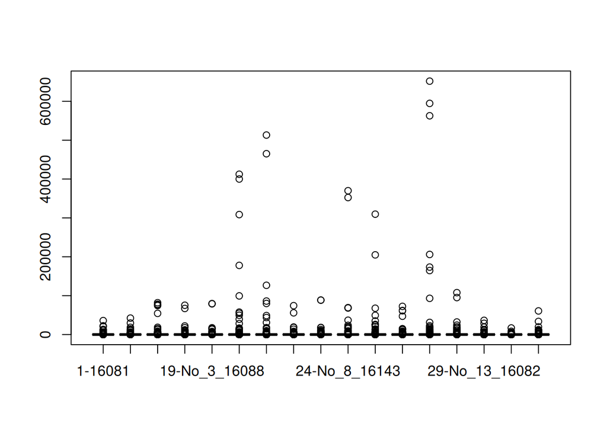

```r
## check boxplot
boxplot(counts(deseq_data, normalized = TRUE))
```

# 4 PCA

Principle component analysis (PCA) is a parametric method, and our data isn’t normally distributed, but we can make it normal with a log transformation.

We can’t log transform 0 so we’ll need to deal with that.

We also don’t want to just directly log transform all our data as RNA seq data is [heteroscedastic](https://en.wikipedia.org/wiki/Heteroscedasticity), meaning its variance are not stable across the data. So small counts are highly variable, but high counts are much more stable.

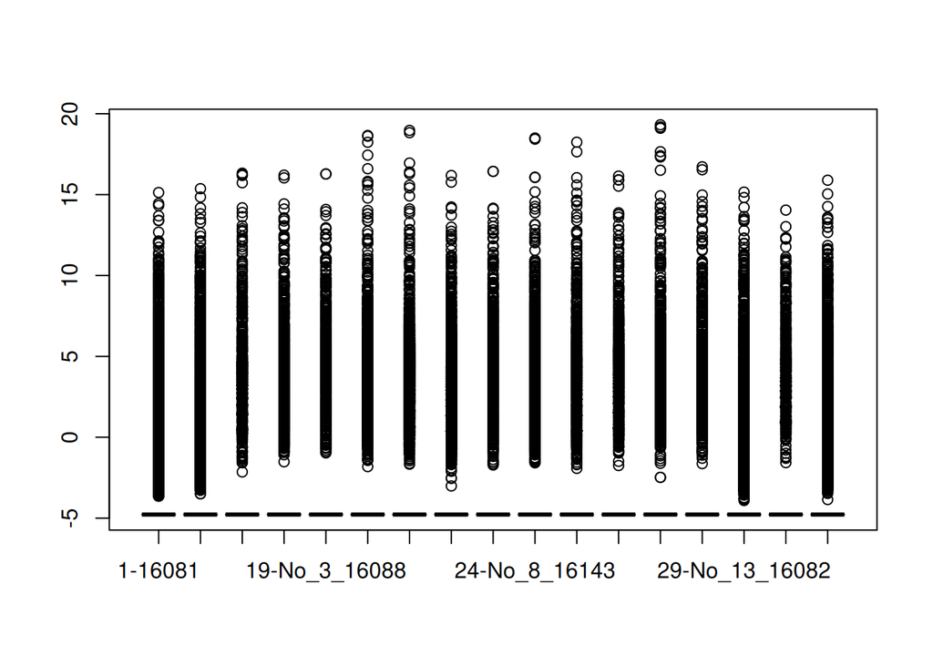

```r
## apply log transformation
vst = varianceStabilizingTransformation(deseq_data)
## plot transformed data
boxplot(assay(vst))
```

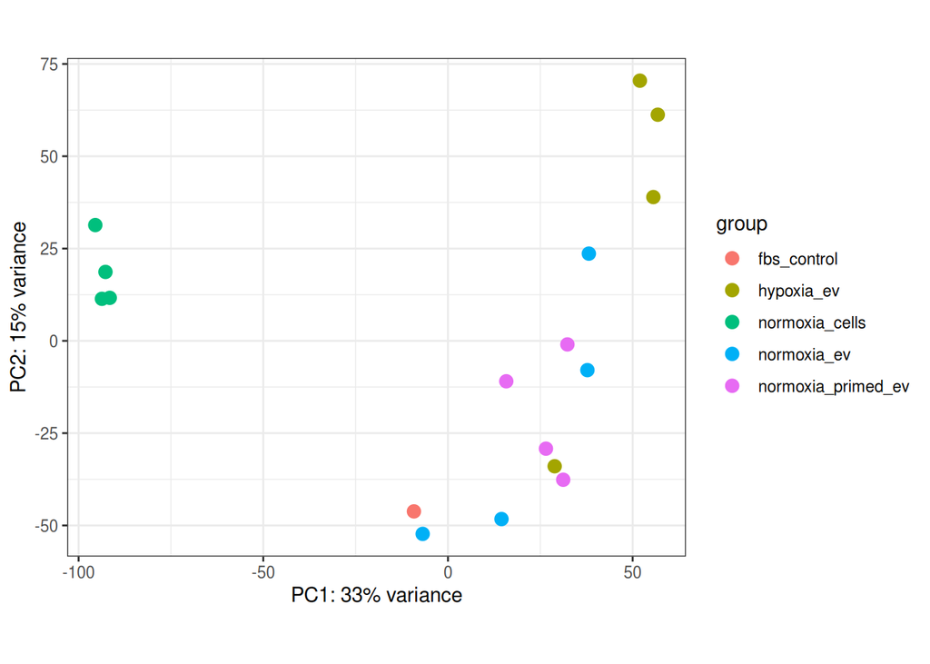

```r
## plot pca - not that this only used the first 500 genes
plotPCA(vst, intgroup = 'treatment') +
    theme_bw()
```

It looks like normoxia cells are rather different from the EVs.

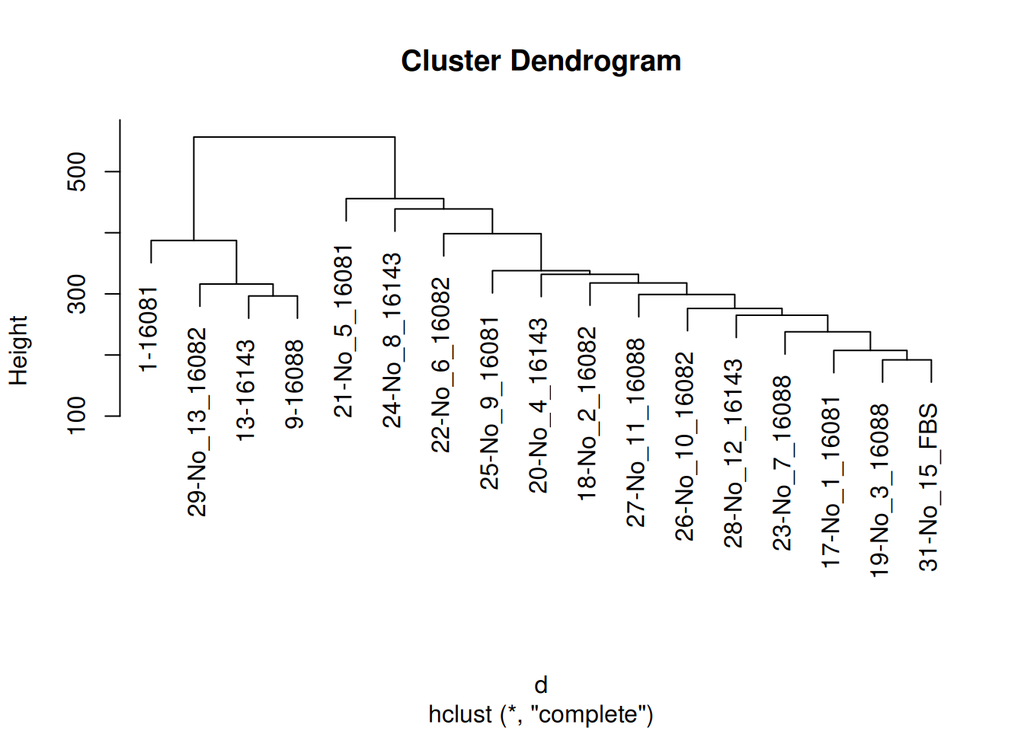

```r
## try some other kinds of clustering

## Hierarchical clustering - unsupervised clustering
## first we need distance measures
d = dist(t(assay(vst)))
## then get clustering
h = hclust(d)
## plot
plot(h)
```

```r
## K-means clustering - supervised clustering
k = kmeans(t(assay(vst)), centers = 2)
k$cluster
```

```
##        1-16081       13-16143  17-No_1_16081  18-No_2_16082  19-No_3_16088  20-No_4_16143  21-No_5_16081  22-No_6_16082  23-No_7_16088  24-No_8_16143  25-No_9_16081 26-No_10_16082 27-No_11_16088 28-No_12_16143 29-No_13_16082
##              2              2              1              1              1              1              1              1              1              1              1              1              1              1              2
##   31-No_15_FBS        9-16088
##              1              2
```

# 5 Dispersions

Dispersion is a measure of variance.

This is the sum of two components, the biological variance, the naturally occurring stochastic variance which we can estimate from our data, and the shot noise, which is the systematic experimental variation.

For low gene expression the shot noise, or technical variation, is what dominates, whereas biological variation is more relevant at higher counts.

We need to estimate the variance as we would need an impractical number of measurements to calculate it more exactly.

DESeq2 can compare the variance of all measurements of all genes, as opposed to all measurements of one gene which we can do because the gene counts are not completely independent of one another, to shrink the estimate of variance for current gene. This is called [empirical bayesian shrinkage](https://www.ncbi.nlm.nih.gov/pmc/articles/PMC2872278/).

In the dispersion plots the black points are the raw estimates of dispersion for each gene. The red points are the relationship between the mean counts with the mean dispersion. The black points are then shrunk to the red line which is denoted by the blue points.

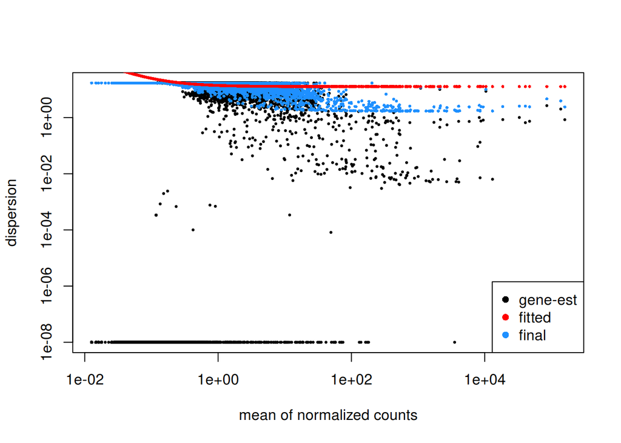

```r
dds <- estimateDispersions(deseq_data)
plotDispEsts(dds)
```

```r
dds <- nbinomWaldTest(dds)
## note that DESeq2 has a function apply the above three methods as a shortcut like so
dds2 <- DESeq(deseq_data_in)

## get results
result_table = results(dds)
result_table2 = results(dds2)
summary(result_table)
```

```
##
## out of 17194 with nonzero total read count
## adjusted p-value < 0.1
## LFC > 0 (up)       : 1, 0.0058%
## LFC < 0 (down)     : 0, 0%
## outliers [1]       : 90, 0.52%
## low counts [2]     : 0, 0%
## (mean count < 0)
## [1] see 'cooksCutoff' argument of ?results
## [2] see 'independentFiltering' argument of ?results
```

```r
summary(result_table2)
```

```
##
## out of 17194 with nonzero total read count
## adjusted p-value < 0.1
## LFC > 0 (up)       : 1, 0.0058%
## LFC < 0 (down)     : 0, 0%
## outliers [1]       : 90, 0.52%
## low counts [2]     : 0, 0%
## (mean count < 0)
## [1] see 'cooksCutoff' argument of ?results
## [2] see 'independentFiltering' argument of ?results
```

```r
## note that summary output is the same

head(result_table)
```

```
## log2 fold change (MLE): treatment normoxia primed ev vs fbs control
## Wald test p-value: treatment normoxia primed ev vs fbs control
## DataFrame with 6 rows and 6 columns
##                  baseMean log2FoldChange     lfcSE       stat    pvalue      padj
##                 <numeric>      <numeric> <numeric>  <numeric> <numeric> <numeric>
## ENSG00000000003 0.0147187      -0.277269   7.02959 -0.0394432  0.968537  0.973947
## ENSG00000000005 0.0000000             NA        NA         NA        NA        NA
## ENSG00000000419 0.1030310      -0.277368   7.02959 -0.0394572  0.968526  0.973947
## ENSG00000000457 1.5877175      -0.277466   7.02959 -0.0394712  0.968515  0.973947
## ENSG00000000460 0.0000000             NA        NA         NA        NA        NA
## ENSG00000000938 0.0000000             NA        NA         NA        NA        NA
```